# STAT 240 Discussion 4

### 5

> Read in the data for Denver using the appropriate `read_*()` command. Make a line plot that shows the total number of international flights arriving to Denver international airport by month. (Note: add `group = 1` as an aesthetic so that there is a single line for all months.)

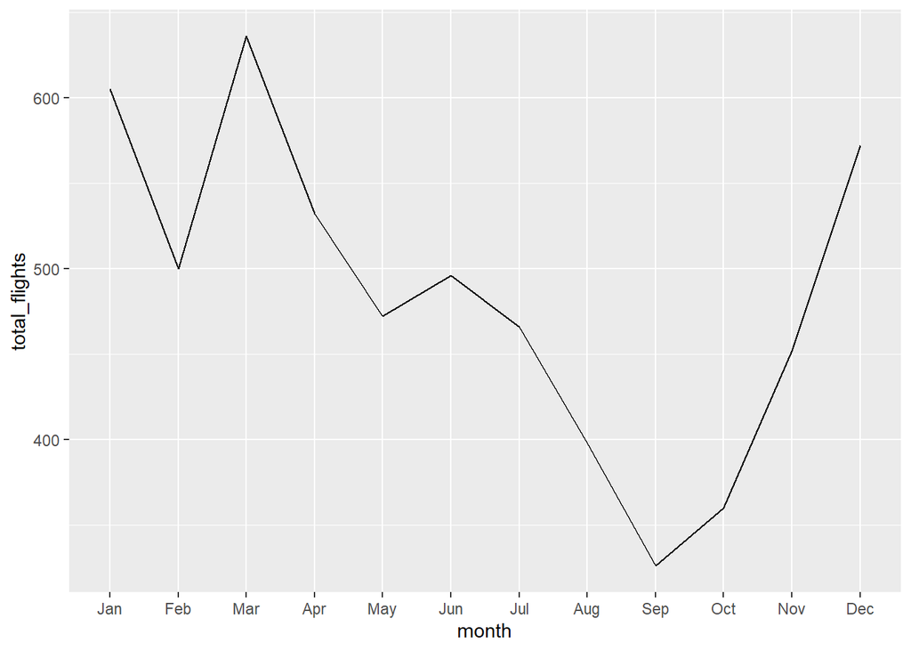

```r
den = read_csv("../../data/denver-2018.csv") %>%
  ## removes cols whose names end with 'wait'
  select(-ends_with("wait")) %>%
  ## removes cols whose names contain '_n_'
  select(-contains("_n_")) %>%
  ## removes cols terminal, hour, all_excluded, all_booths
  select(-terminal,-hour,-all_excluded,-all_booths) %>%
  ## renames col all_total to passengers and col all_flights to flights
  rename(passengers = all_total,
         flights = all_flights) %>%
  group_by(airport,date) %>%
  ## modify passenger and flight cols so they show the sums of the respective categories
  summarize(passengers = sum(passengers),
            flights = sum(flights)) %>%
  ## modifies date to be in month-day-year form
  mutate(date = mdy(date)) %>%
  ## add new wday col to display weekday in string form
  mutate(wday = wday(date, label=TRUE)) %>%
  ## add new month col to display month in string form
  mutate(month = month(date, label=TRUE)) %>%
  ## reorders the cols as below
  select(airport,date,month,wday,everything()) %>%
  ## orders cols in asc date order
  arrange(date)

den_flights <- den %>%
  select(month, flights) %>%
  group_by(month) %>%
  summarize(total_flights = sum(flights))

ggplot(den_flights, mapping=aes(month, total_flights)) +
  geom_line(group = '1')
```

### Lubridate practice

Code below creates a datetime object with the current date and time. Write one line of code to extract from this datetime the requested information. (Your answers will depend on the exact time you knit the document.)

```r
now_dt = now()
```

### 6

> The year

```r
year(now_dt)
```

```
## [1] 2020
```

### 7

> The month as a number

```r
month(now_dt)
```

```
## [1] 9
```

### 8

> The day of the week as a number

```r
wday(now_dt)
```

```
## [1] 2
```

### 9

> The day of the week as a label

```r
wday(now_dt, label=TRUE)
```

```
## [1] Mon
## Levels: Sun < Mon < Tue < Wed < Thu < Fri < Sat
```

### 10

> The hour

```r
hour(now_dt)
```

```
## [1] 12
```